# NOAA Storm Data Analysis

Mugenyi Raymond

7/15/2021

## Synopsis

Storms and other severe weather events can cause both public health and economic problems for communities and municipalities. Many severe events can result in fatalities, injuries, crop and property damage, and preventing such outcomes to the extent possible is a key concern.By using U.S. National Oceanic and Atmospheric Administration’s (NOAA) storm database, two main questions are addressed.These are; “which types of events are most harmful with respect to population health?” and “which types of events have the greatest economic consequences?”. In the analysis, it was found out that TORNADO is the most harmful event type with respect to population health and Flood has the greatest economic consequences across United States!

## **Data Processing**

The data was downloaded from the url: http://d396qusza40orc.cloudfront.net/repdata%2Fdata%2FStormData.csv.bz2 and it was then unzipped using the bunzip2 function from the R.utils package.

```r
library(R.utils)
```

```r
fileurl <-  "http://d396qusza40orc.cloudfront.net/repdata%2Fdata%2FStormData.csv.bz2"
download.file(fileurl, destfile =  "NOOAstormdata.csv.bz2")
bunzip2("NOOAstormdata.csv.bz2") # unzipping the stormdata
data <-  read.csv("NOOAstormdata.csv") #reading in the data
```

## *Question 1: Across the United States, which types of events are most harmful with respect to population health?*

Here we shall explore and find out which event causes most injuries and fatalities At first lets select the key variables relevant in this analysis. These are; EVTYPE , FATALITIES , INJURIES, PROPDMG, CROPDMG, PROPDMGEXP, and CROPDMGEXP.

```r
library(dplyr)
data <- select(data, c("EVTYPE", "FATALITIES", "INJURIES", "PROPDMG", "CROPDMG", "PROPDMGEXP", "CROPDMGEXP" ))
injuries <- aggregate(data$INJURIES, by = list(data$EVTYPE), FUN = sum) %>%
  rename(event_type = "Group.1", total_injuries = "x") %>% arrange(desc(total_injuries))
```

```r
#plot
library(ggplot2)
bar_plot_injuries <- ggplot(injuries[1:5,], aes(event_type, total_injuries)) +
  geom_bar(stat = "identity" , aes(fill = event_type)) +
  labs(x = "Type of Event", y = "Total injuries",
       title = "Total injuries by Event Type",
       caption = "Figure 1: Only the first 5 devastating events are shown.
       Tornado shows highest number of injuries followed by TSTM Wind,
       Flood,Excessive heat and lastly Lightning.") +
  theme(plot.title = element_text(hjust = 0.5), plot.caption = element_text(size = 8.5,hjust = 0.5))
```

For the event type causing most fatalities;

```r
library(dplyr)
fatalities <- aggregate(data$FATALITIES, by = list(data$EVTYPE), FUN = sum) %>%
  rename(event_type = "Group.1", total_fatalities = "x") %>% arrange(desc(total_fatalities))

# plot
library(ggplot2)
bar_plot_fatalities <- ggplot(fatalities[1:5,], aes(event_type, total_fatalities)) +
  geom_bar(stat = "identity" , aes(fill = event_type)) +
  labs(x = "Type of Event",
       y = "Total fatalities",
       title = "Total fatalities by Event Type",
       caption = "Figure 2:Only the first 5 devastating event types are shown.
       Tornado shows the highest number of fatalities followed by Excessive heat,
       Flash flood, Heat, and lastly Lightning.") +
  theme(plot.title = element_text(hjust = 0.5), plot.caption = element_text(size = 8.5, hjust = 0.5))
```

## *Question 2: Across the United States, which types of events have the greatest economic consequences?*

To address this question, we have to explore the property damange, crop damage and the total damage (property damage and crop damage combined). Let us begin with the property damage. By looking at the PROPDMGEXP exponents;

```r
unique(data$PROPDMGEXP)
```

```
##  [1] "K" "M" ""  "B" "m" "+" "0" "5" "6" "?" "4" "2" "3" "h" "7" "H" "-" "1" "8"
```

We see some lower case characters for example “m” instead of “M”. We also see some symbols such as “+”. We shall change lower case characters to upper case characters and also set all symbols to zero character (since the class of the exponents is character)

```r
data$PROPDMGEXP <- toupper(data$PROPDMGEXP)
data$PROPDMGEXP[data$PROPDMGEXP %in% c("", "+", "?", "-")] <-  "0"
```

Since PROPDMGEXP stands for the power of 10, we need to convert “B” (for billions) to 9, “M”( for millions) to 6, “K” ( for thousands) to 3 and “H” (for hundreds) to 2.

```r
data$PROPDMGEXP[data$PROPDMGEXP == "B"] <- "9"
data$PROPDMGEXP[data$PROPDMGEXP == "M"] <- "6"
data$PROPDMGEXP[data$PROPDMGEXP == "K"] <- "3"
data$PROPDMGEXP[data$PROPDMGEXP == "H"] <- "2"
```

We shall now convert the character class of PROPDMGEXP variable to numeric class and calculating the true damage by multiplying the damage by the corresponding exponent.Then we shall arrange true.property.damage variable in descending order to find out which even shows the greatest damage in terms of economic loss.

```r
library(dplyr)
data$PROPDMGEXP <- 10^(as.numeric(data$PROPDMGEXP))
damage <- mutate(data, true.property.damage = PROPDMG*PROPDMGEXP)
damage1 <- aggregate(damage$true.property.damage, by = list(damage$EVTYPE), FUN = sum)%>%  rename(Event.type = "Group.1", total.property.damage = "x") %>%
  arrange(desc(total.property.damage))
```

```r
unique(damage$CROPDMGEXP)
```

```
## [1] ""  "M" "K" "m" "B" "?" "0" "k" "2"
```

Converting lower case characters to uppercase characters and also setting symbols to zero

```r
damage$CROPDMGEXP <- toupper(damage$CROPDMGEXP)
damage$CROPDMGEXP[damage$CROPDMGEXP %in% c("", "+", "?", "-")] <-  "0"
```

Since CROPDMGEXP stands for the power of 10, we need to convert ‘B’ (for billions) to 9, ‘M’( for millions) to 6, ‘K’ ( for thousands) to 3 and ‘H’(for hundreds) to 2;

```r
damage$CROPDMGEXP[damage$CROPDMGEXP == "B"] <- "9"
damage$CROPDMGEXP[damage$CROPDMGEXP == "M"] <- "6"
damage$CROPDMGEXP[damage$CROPDMGEXP == "K"] <- "3"
damage$CROPDMGEXP[damage$CROPDMGEXP == "H"] <- "2"
```

converting the character class of CROPDMGEXP variable to numeric class and calculating the true damage by multiplying the damage by the corresponding exponent.

```r
library(dplyr)
damage$CROPDMGEXP <- 10^(as.numeric(damage$CROPDMGEXP))
damagex <- mutate(damage, true.crop.damage = CROPDMG*CROPDMGEXP)
damage2 <- aggregate(damagex$true.crop.damage, by = list(damagex$EVTYPE), FUN = sum) %>%
  rename(Event.type = "Group.1", total.crop.damage = "x") %>%
  arrange(desc(total.crop.damage))
```

Finding the total damage by getting the sum of damage to property and that of crops

```r
Total_damage <- merge(damage1,damage2) %>%
  mutate(total.damage = total.property.damage + total.crop.damage) %>%
  arrange(desc(total.damage)) %>%
  select(c("Event.type", "total.damage"))
#plot
library(ggplot2)
bar_plot_total_damage <- ggplot(Total_damage[1:5,], aes(Event.type, total.damage))+
  geom_bar(aes(fill = Event.type), stat = "identity") +
  labs(x = "Type of event",
       y = "Total Damage",
       title = "Total damage by Event type",
       caption = "Figure 3 : Only the first 5 devastating event types are shown.
       Flood shows the highest damage followed by Hurricane/Typhoon, Tornado, Storm surge,
       and lastly Hail." )+
  theme(plot.title = element_text(hjust = 0.5), plot.caption = element_text(size = 8.5, hjust = 0.5))
```

## **Results**

### *Question 1*

For the event type causing most injuries;

```r
head(injuries)
```

```
##       event_type total_injuries
## 1        TORNADO          91346
## 2      TSTM WIND           6957
## 3          FLOOD           6789
## 4 EXCESSIVE HEAT           6525
## 5      LIGHTNING           5230
## 6           HEAT           2100
```

we can see that TORNADO causes the most injuries (over 91,000).So we can conclude that if we consider injuries, TORNADO is the most harmful event with respect to population health. This is further shown in the figure below (only the first 5 events are shown).

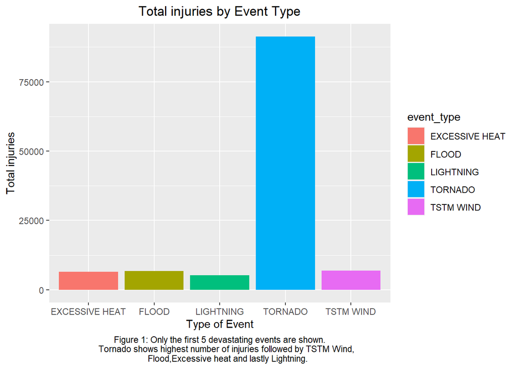

```r
#plot
print(bar_plot_injuries)
```

For the event type causing most fatalities;

```r
head(fatalities)
```

```
##       event_type total_fatalities
## 1        TORNADO             5633
## 2 EXCESSIVE HEAT             1903
## 3    FLASH FLOOD              978
## 4           HEAT              937
## 5      LIGHTNING              816
## 6      TSTM WIND              504
```

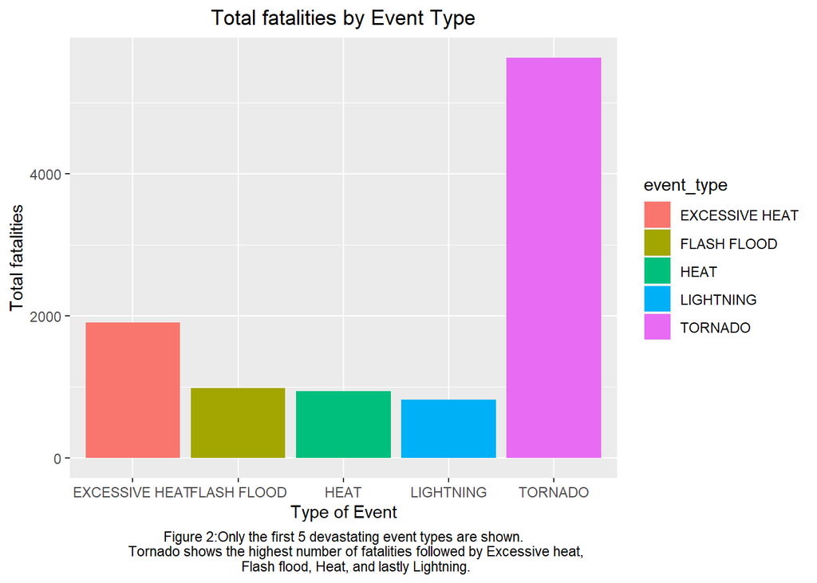

```r
# plot
print(bar_plot_fatalities)
```

**Conclusion** : After considering the injuries and fatalities caused by the event types, it is realized that TORNADO is the most harmful one with respect to population health across United States.

### *Question 2*

```r
head(damage1)
```

```
##          Event.type total.property.damage
## 1             FLOOD          144657709807
## 2 HURRICANE/TYPHOON           69305840000
## 3           TORNADO           56947380677
## 4       STORM SURGE           43323536000
## 5       FLASH FLOOD           16822673979
## 6              HAIL           15735267513
```

```r
data.frame(Event.type = damage1$Event.type[which.max(damage1$total.property.damage)],
Amount.dollars = damage1$total.property.damage[which.max(damage1$total.property.damage)])
```

```
##   Event.type Amount.dollars
## 1      FLOOD   144657709807
```

we see that Flood shows the greatest economic loss when it comes to property damage with over 144 billion dollars!

```r
head(damage2)
```

```
##    Event.type total.crop.damage
## 1     DROUGHT       13972566000
## 2       FLOOD        5661968450
## 3 RIVER FLOOD        5029459000
## 4   ICE STORM        5022113500
## 5        HAIL        3025954473
## 6   HURRICANE        2741910000
```

```r
data.frame(Event.type= damage2$Event.type[which.max(damage2$total.crop.damage)],
           Amount.dollars = damage2$total.crop.damage[which.max(damage2$total.crop.damage)])
```

```
##   Event.type Amount.dollars
## 1    DROUGHT    13972566000
```

we can see that Drought shows the greatest economic loss when it comes to crop damage with over 13 billion dollars!

```r
head(Total_damage)
```

```
##          Event.type total.damage
## 1             FLOOD 150319678257
## 2 HURRICANE/TYPHOON  71913712800
## 3           TORNADO  57362333947
## 4       STORM SURGE  43323541000
## 5              HAIL  18761221986
## 6       FLASH FLOOD  18243991079
```

```r
data.frame(Event.type= Total_damage$Event.type[which.max(Total_damage$total.damage)],
           Amount.dollars = Total_damage$total.damage[which.max(Total_damage$total.damage)])
```

```
##   Event.type Amount.dollars
## 1      FLOOD   150319678257
```

We can see that Flood causes the most damage with a huge economic loss of over 150 billion dollars. This can be shown more clearly by looking at the figure below:

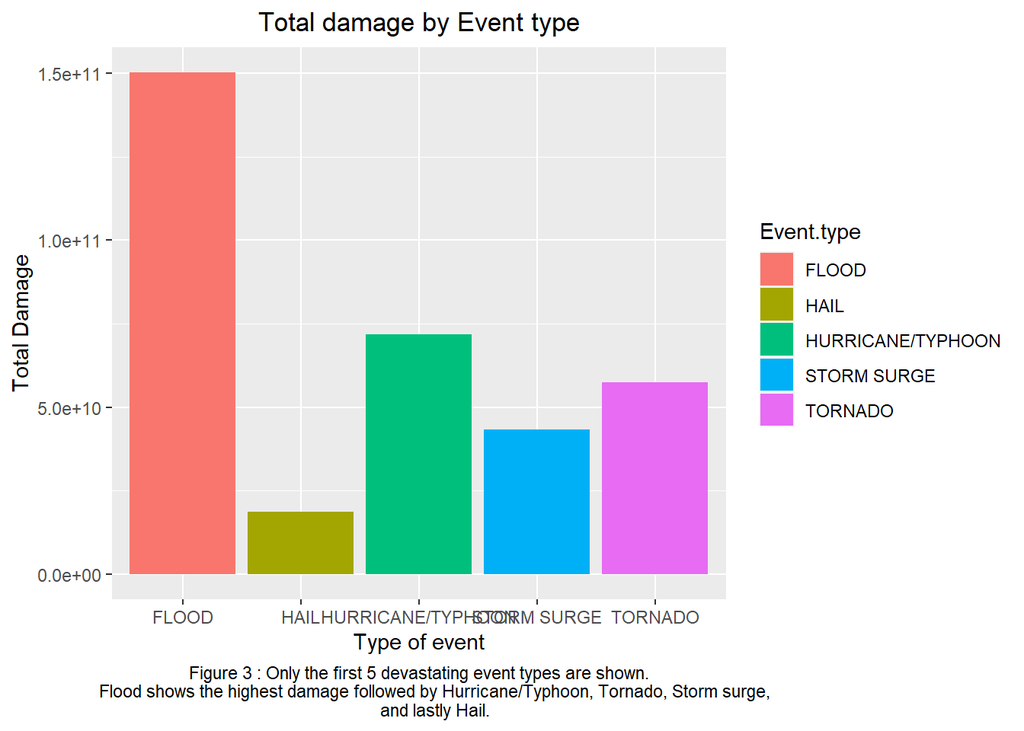

```r
print(bar_plot_total_damage)
```

**Conclusion** : After combining the economic loss due to property and crop damage, Flood event emerges as the most devastating event with greatest economic consequences across the United States!*